# Tarea 3

*Nombres y apellidos*: Joaquín Paolo Mori Reinoso

*Código*: 20211686

En el presente trabajo, se realizará una red de Alcaldes distritales de Lima Metropolitana de los periodos 2019-2022 y 2023-2026. Se observarán las conexiones entre los alcaldes de acuerdo a 3 factores: el partido con el que obtuvieron el cargo público, si fueron alcaldes del mismo distrito y si han sid reelectos o formanparte de un clan electoral (en otras palabras, que familiares hayan ocupado el mismo cargo público con anterioridad).

## Preparación de la data y los grafos

```python
import pandas as pd
LinkToData="https://docs.google.com/spreadsheets/d/1giqur_wkQRyIRE1WjnQmoEo-4LwPEXhxKzJ6QoV7-c8/export?format=csv"
AlcalLima = pd.read_csv(LinkToData,
                          index_col=0)
```

```python
AlcalLima.head()
```

|  | Daysa Taype (PP) | Franco Vidal (Avanza País) | Jessica Vargas (Renovación Popular) | Luis De La Mata (PP) | Pablo Mendoza (Somos Perú) | Emilio Chávez (PP) | Ulises Villegas (Somos Perú) | Sergio Baigorrea (Renovación Popular) | Fernando Velzco (APP) | Richard Soria (PP) | ... | Juan Nole (PPC) | Jiries Jamis (Restauración Nacional) | Alan Carrasco (Somos Perú) | Jean Combre (AP) | Giancarlo Cassasa (PPC) | Clodoaldo Iñigo (Perú Patria Segura) | Guido Yñigo (Perú Patria Segura) | J. R. Marticorena (APP) | J. J. Marticorena (Somos Perú) | Reelección/Clan |
| --- | --- | --- | --- | --- | --- | --- | --- | --- | --- | --- | --- | --- | --- | --- | --- | --- | --- | --- | --- | --- | --- |
| Daysa Taype (PP) | 1 | 0 | 0 | 1 | 0 | 1 | 0 | 0 | 0 | 1 | ... | 0 | 0 | 0 | 0 | 0 | 0 | 0 | 0 | 0 | 0 |
| Franco Vidal (Avanza País) | 0 | 1 | 0 | 0 | 0 | 0 | 0 | 0 | 0 | 0 | ... | 0 | 0 | 0 | 0 | 0 | 0 | 0 | 0 | 0 | 0 |
| Jessica Vargas (Renovación Popular) | 0 | 0 | 1 | 0 | 0 | 0 | 0 | 1 | 0 | 0 | ... | 0 | 0 | 0 | 0 | 0 | 0 | 0 | 0 | 0 | 0 |
| Luis De La Mata (PP) | 1 | 0 | 0 | 1 | 0 | 1 | 0 | 0 | 0 | 1 | ... | 0 | 0 | 0 | 0 | 0 | 0 | 0 | 0 | 0 | 0 |
| Pablo Mendoza (Somos Perú) | 0 | 0 | 0 | 0 | 1 | 0 | 1 | 0 | 0 | 0 | ... | 0 | 0 | 1 | 0 | 0 | 0 | 0 | 0 | 1 | 0 |

5 rows × 84 columns

```python
varsToDrop=['Reelección/Clan']
Alcaldes=AlcalLima.drop(varsToDrop,axis=1)

Alcaldes
```

|  | Daysa Taype (PP) | Franco Vidal (Avanza País) | Jessica Vargas (Renovación Popular) | Luis De La Mata (PP) | Pablo Mendoza (Somos Perú) | Emilio Chávez (PP) | Ulises Villegas (Somos Perú) | Sergio Baigorrea (Renovación Popular) | Fernando Velzco (APP) | Richard Soria (PP) | ... | Juan Guevara (San Miguel Me Gusta) | Juan Nole (PPC) | Jiries Jamis (Restauración Nacional) | Alan Carrasco (Somos Perú) | Jean Combre (AP) | Giancarlo Cassasa (PPC) | Clodoaldo Iñigo (Perú Patria Segura) | Guido Yñigo (Perú Patria Segura) | J. R. Marticorena (APP) | J. J. Marticorena (Somos Perú) |
| --- | --- | --- | --- | --- | --- | --- | --- | --- | --- | --- | --- | --- | --- | --- | --- | --- | --- | --- | --- | --- | --- |
| Daysa Taype (PP) | 1 | 0 | 0 | 1 | 0 | 1 | 0 | 0 | 0 | 1 | ... | 0 | 0 | 0 | 0 | 0 | 0 | 0 | 0 | 0 | 0 |
| Franco Vidal (Avanza País) | 0 | 1 | 0 | 0 | 0 | 0 | 0 | 0 | 0 | 0 | ... | 0 | 0 | 0 | 0 | 0 | 0 | 0 | 0 | 0 | 0 |
| Jessica Vargas (Renovación Popular) | 0 | 0 | 1 | 0 | 0 | 0 | 0 | 1 | 0 | 0 | ... | 0 | 0 | 0 | 0 | 0 | 0 | 0 | 0 | 0 | 0 |
| Luis De La Mata (PP) | 1 | 0 | 0 | 1 | 0 | 1 | 0 | 0 | 0 | 1 | ... | 0 | 0 | 0 | 0 | 0 | 0 | 0 | 0 | 0 | 0 |
| Pablo Mendoza (Somos Perú) | 0 | 0 | 0 | 0 | 1 | 0 | 1 | 0 | 0 | 0 | ... | 0 | 0 | 0 | 1 | 0 | 0 | 0 | 0 | 0 | 1 |
| ... | ... | ... | ... | ... | ... | ... | ... | ... | ... | ... | ... | ... | ... | ... | ... | ... | ... | ... | ... | ... | ... |
| Giancarlo Cassasa (PPC) | 0 | 0 | 0 | 0 | 0 | 0 | 0 | 0 | 0 | 0 | ... | 0 | 1 | 0 | 0 | 0 | 1 | 0 | 0 | 0 | 0 |
| Clodoaldo Iñigo (Perú Patria Segura) | 0 | 0 | 0 | 0 | 0 | 0 | 0 | 0 | 0 | 0 | ... | 0 | 0 | 0 | 0 | 0 | 0 | 1 | 1 | 0 | 0 |
| Guido Yñigo (Perú Patria Segura) | 0 | 0 | 0 | 0 | 0 | 0 | 0 | 0 | 0 | 0 | ... | 0 | 0 | 0 | 0 | 0 | 0 | 1 | 1 | 0 | 0 |
| J. R. Marticorena (APP) | 0 | 0 | 0 | 0 | 0 | 0 | 0 | 0 | 1 | 0 | ... | 0 | 0 | 0 | 0 | 0 | 0 | 0 | 0 | 1 | 1 |
| J. J. Marticorena (Somos Perú) | 0 | 0 | 0 | 0 | 1 | 0 | 1 | 0 | 0 | 0 | ... | 0 | 0 | 0 | 1 | 0 | 0 | 0 | 0 | 1 | 1 |

83 rows × 83 columns

```python
import networkx as nx
Alcaldes = nx.from_pandas_adjacency(AlcalLima)
Alcaldes.remove_edges_from(nx.selfloop_edges(Alcaldes))
```

```python
type(Alcaldes)
```

```
networkx.classes.graph.Graph
```

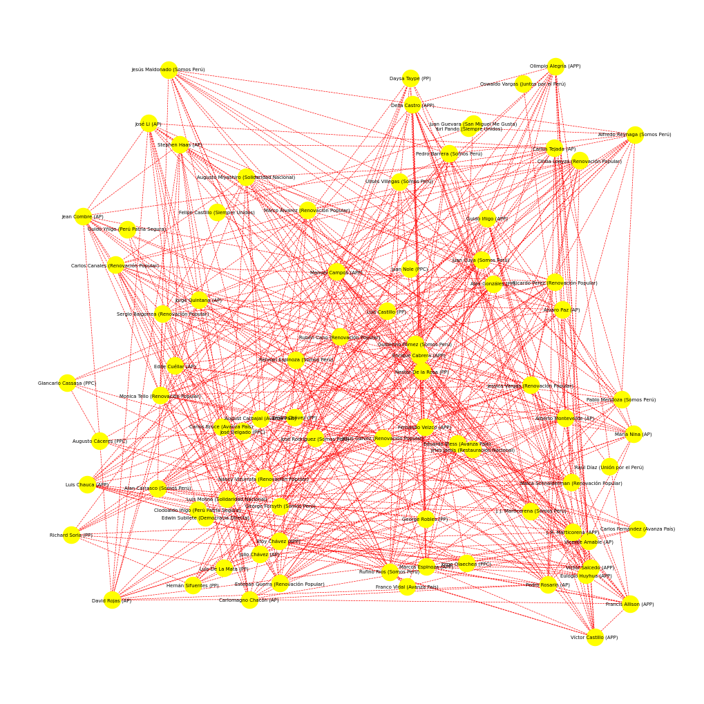

```python
import networkx as nx
import matplotlib.pyplot as plt

plt.figure(figsize=(10, 10))
nx.draw_random(Alcaldes,
               node_color='yellow',
               edge_color='red',
               with_labels=True,
               font_size=5,
               width=0.5,
               style='dashed')


plt.savefig("grafico_alcaldes.png", format='png', bbox_inches='tight')
plt.show()
```

```python
dict(zip(AlcalLima.index,AlcalLima['Reelección/Clan']))
```

```
{'Daysa Taype (PP)': 0,
 'Franco Vidal (Avanza País)': 0,
 'Jessica Vargas (Renovación Popular)': 0,
 'Luis De La Mata (PP)': 0,
 'Pablo Mendoza (Somos Perú)': 0,
 'Emilio Chávez (PP)': 1,
 'Ulises Villegas (Somos Perú)': 0,
 'Sergio Baigorrea (Renovación Popular)': 0,
 'Fernando Velzco (APP)': 0,
 'Richard Soria (PP)': 1,
 'Alfredo Reynaga (Somos Perú)': 0,
 'Jesús Galvez (Renovación Popular)': 0,
 'Esteban Guerra (Renovación Popular)': 0,
 'Rubén Cano (Renovación Popular)': 0,
 'Malca Schnaiderman (Renovación Popular)': 0,
 'Luis Castillo (PP)': 1,
 'Oswaldo Vargas (Juntos por el Perú)': 0,
 'Francis Allison (APP)': 1,
 'Carlos Canales (Renovación Popular)': 0,
 'Enrique Cabrera (APP)': 0,
 'Juan Cuya (Somos Perú)': 1,
 'Monica Tello (Renovación Popular)': 0,
 'Rennan Espinoza (Somos Perú)': 1,
 'Carlos Fernández (Avanza País)': 1,
 'Eulogio Huyhua (APP)': 0,
 'Nestor De la Rosa (PP)': 0,
 'August Carbajal (Avanza País)': 0,
 'Marco Álvarez (Renovación Popular)': 1,
 'Nancy Vizurrafa (Renovación Popular)': 0,
 'Jesús Maldonado (Somos Perú)': 0,
 'Delia Castro (APP)': 0,
 'Ricardo Perez (Renovación Popular)': 0,
 'Hernán Sifuentes (PP)': 0,
 'Eduardo Bless (Avanza País)': 0,
 'Olimpio Alegría (APP)': 0,
 'Alberto Monteverde (AP)': 0,
 'George Robles (PP)': 0,
 'Carlos Bruce (Avanza País)': 0,
 'Cintia Loayza (Renovación Popular)': 0,
 'Guido Iñigo (APP)': 1,
```

[output cut: 28 more lines]

```
 'Augusto Cáceres (PPC)': 0,
 'Alex Gonzáles (PP)': 0,
 'María Nina (AP)': 0,
 'David Rojas (AP)': 0,
 'Julio Chávez (AP)': 0,
 'Juan Guevara (San Miguel Me Gusta)': 0,
 'Juan Nole (PPC)': 0,
 'Jiries Jamis (Restauración Nacional)': 0,
 'Alan Carrasco (Somos Perú)': 0,
 'Jean Combre (AP)': 0,
 'Giancarlo Cassasa (PPC)': 0,
 'Clodoaldo Iñigo (Perú Patria Segura)': 1,
 'Guido Yñigo (Perú Patria Segura)': 0,
 'J. R. Marticorena (APP)': 1,
 'J. J. Marticorena (Somos Perú)': 1}
```

```python
attributeToAdd=dict(zip(AlcalLima.index,AlcalLima['Reelección/Clan']))
nx.set_node_attributes(Alcaldes, attributeToAdd,'Clan')
```

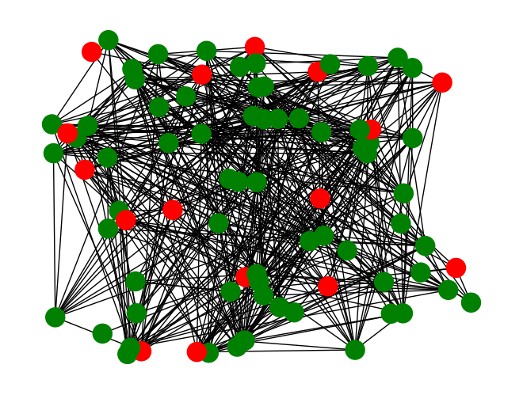

```python
colors={e:'red' if v==1 else 'green' for e,v in nx.get_node_attributes(Alcaldes,"Clan").items()}
nx.set_node_attributes(Alcaldes, colors, "color")
nx.draw_random(Alcaldes,node_color=nx.get_node_attributes(Alcaldes, "color").values())
```

## Exploración

Se explorará la información acerca del tipo de grafo. En este caso, se realizó un grafo con 83 nodos (todos los alcaldes de Lima Metropolitana en las dos elecciones) y sus conexiones totales. Del mismo modo, este es un grafo no dirigido.

```python
# type of network
type(Alcaldes)
```

```
networkx.classes.graph.Graph
```

```python
len(Alcaldes.nodes),len(Alcaldes.edges)
```

```
(83, 463)
```

## Conectividad

Se observará la conectividad de los nodos en el grafo de alcaldes. Dado que todos están conectados (por partido, distrito o clan) el grafo muestra que solo tiene un grupo que contiene todos los nodos.

```python
nx.is_connected(Alcaldes)
```

```
True
```

```python
len(list(nx.connected_components(Alcaldes)))
```

```
1
```

```python
[len(c) for c in sorted(nx.connected_components(Alcaldes), key=len, reverse=True)]
```

```
[83]
```

¿Qué nodos (alcaldes) están en solitario? Se espera que ninguno ya que todos están conectados por algún factor ya mencionado.

```python
list(nx.isolates(Alcaldes))
```

```
[]
```

## Distancia

Se observa la distancia de los grafos entre sí. Como todos los nodos están conectados entre sí, la distancia mayor entre dos nodos y la distancia total son iguales.

```python
 nx.diameter(Alcaldes)
```

```
7
```

```python
largest_cc_nodes = max(nx.connected_components(Alcaldes), key=len)
Alcaldes_largest=Alcaldes.subgraph(largest_cc_nodes)

nx.diameter(Alcaldes_largest)
```

```
7
```

```python
# geodesics
geodesics = dict(nx.all_pairs_shortest_path_length(Alcaldes))

# as matrix
MatrixGeo = [[geodesics.get(n,{}).get(m)  for m in Alcaldes.nodes] for n in Alcaldes.nodes]

# as DF (pandas)
MatrixGeo_DF=pd.DataFrame(MatrixGeo,index=Alcaldes.nodes, columns=Alcaldes.nodes)

# we get
MatrixGeo_DF
```

|  | Daysa Taype (PP) | Franco Vidal (Avanza País) | Jessica Vargas (Renovación Popular) | Luis De La Mata (PP) | Pablo Mendoza (Somos Perú) | Emilio Chávez (PP) | Ulises Villegas (Somos Perú) | Sergio Baigorrea (Renovación Popular) | Fernando Velzco (APP) | Richard Soria (PP) | ... | Juan Guevara (San Miguel Me Gusta) | Juan Nole (PPC) | Jiries Jamis (Restauración Nacional) | Alan Carrasco (Somos Perú) | Jean Combre (AP) | Giancarlo Cassasa (PPC) | Clodoaldo Iñigo (Perú Patria Segura) | Guido Yñigo (Perú Patria Segura) | J. R. Marticorena (APP) | J. J. Marticorena (Somos Perú) |
| --- | --- | --- | --- | --- | --- | --- | --- | --- | --- | --- | --- | --- | --- | --- | --- | --- | --- | --- | --- | --- | --- |
| Daysa Taype (PP) | 0 | 4 | 3 | 1 | 2 | 1 | 2 | 4 | 3 | 1 | ... | 5 | 4 | 4 | 2 | 3 | 5 | 4 | 4 | 3 | 2 |
| Franco Vidal (Avanza País) | 4 | 0 | 4 | 3 | 3 | 4 | 3 | 4 | 4 | 4 | ... | 2 | 3 | 3 | 3 | 2 | 3 | 5 | 5 | 4 | 3 |
| Jessica Vargas (Renovación Popular) | 3 | 4 | 0 | 4 | 2 | 4 | 2 | 1 | 2 | 4 | ... | 5 | 3 | 1 | 2 | 3 | 2 | 4 | 4 | 3 | 2 |
| Luis De La Mata (PP) | 1 | 3 | 4 | 0 | 3 | 1 | 3 | 4 | 3 | 1 | ... | 5 | 4 | 3 | 2 | 2 | 5 | 4 | 4 | 3 | 3 |
| Pablo Mendoza (Somos Perú) | 2 | 3 | 2 | 3 | 0 | 3 | 1 | 3 | 2 | 3 | ... | 4 | 3 | 3 | 1 | 4 | 4 | 3 | 3 | 2 | 1 |
| ... | ... | ... | ... | ... | ... | ... | ... | ... | ... | ... | ... | ... | ... | ... | ... | ... | ... | ... | ... | ... | ... |
| Giancarlo Cassasa (PPC) | 5 | 3 | 2 | 5 | 4 | 5 | 4 | 2 | 3 | 4 | ... | 4 | 1 | 2 | 4 | 4 | 0 | 4 | 4 | 3 | 4 |
| Clodoaldo Iñigo (Perú Patria Segura) | 4 | 5 | 4 | 4 | 3 | 4 | 4 | 3 | 2 | 3 | ... | 7 | 3 | 4 | 4 | 4 | 4 | 0 | 1 | 2 | 3 |
| Guido Yñigo (Perú Patria Segura) | 4 | 5 | 4 | 4 | 3 | 4 | 4 | 3 | 2 | 3 | ... | 7 | 3 | 4 | 4 | 4 | 4 | 1 | 0 | 2 | 3 |
| J. R. Marticorena (APP) | 3 | 4 | 3 | 3 | 2 | 3 | 2 | 2 | 1 | 2 | ... | 5 | 2 | 3 | 2 | 3 | 3 | 2 | 2 | 0 | 1 |
| J. J. Marticorena (Somos Perú) | 2 | 3 | 2 | 3 | 1 | 3 | 1 | 3 | 2 | 3 | ... | 4 | 3 | 3 | 1 | 4 | 4 | 3 | 3 | 1 | 0 |

83 rows × 83 columns

```python
import numpy as np

pd.DataFrame(np.unique(MatrixGeo_DF.values, return_counts=True),index=['valor','freq']).T.set_index('valor')
```

| valor | freq |
| --- | --- |
| 0 | 83 |
| 1 | 926 |
| 2 | 1452 |
| 3 | 2434 |
| 4 | 1588 |
| 5 | 340 |
| 6 | 58 |
| 7 | 8 |

```python
MatrixReach_DF=(MatrixGeo_DF>0).replace({True:1,False:0})
MatrixReach_DF
```

|  | Daysa Taype (PP) | Franco Vidal (Avanza País) | Jessica Vargas (Renovación Popular) | Luis De La Mata (PP) | Pablo Mendoza (Somos Perú) | Emilio Chávez (PP) | Ulises Villegas (Somos Perú) | Sergio Baigorrea (Renovación Popular) | Fernando Velzco (APP) | Richard Soria (PP) | ... | Juan Guevara (San Miguel Me Gusta) | Juan Nole (PPC) | Jiries Jamis (Restauración Nacional) | Alan Carrasco (Somos Perú) | Jean Combre (AP) | Giancarlo Cassasa (PPC) | Clodoaldo Iñigo (Perú Patria Segura) | Guido Yñigo (Perú Patria Segura) | J. R. Marticorena (APP) | J. J. Marticorena (Somos Perú) |
| --- | --- | --- | --- | --- | --- | --- | --- | --- | --- | --- | --- | --- | --- | --- | --- | --- | --- | --- | --- | --- | --- |
| Daysa Taype (PP) | 0 | 1 | 1 | 1 | 1 | 1 | 1 | 1 | 1 | 1 | ... | 1 | 1 | 1 | 1 | 1 | 1 | 1 | 1 | 1 | 1 |
| Franco Vidal (Avanza País) | 1 | 0 | 1 | 1 | 1 | 1 | 1 | 1 | 1 | 1 | ... | 1 | 1 | 1 | 1 | 1 | 1 | 1 | 1 | 1 | 1 |
| Jessica Vargas (Renovación Popular) | 1 | 1 | 0 | 1 | 1 | 1 | 1 | 1 | 1 | 1 | ... | 1 | 1 | 1 | 1 | 1 | 1 | 1 | 1 | 1 | 1 |
| Luis De La Mata (PP) | 1 | 1 | 1 | 0 | 1 | 1 | 1 | 1 | 1 | 1 | ... | 1 | 1 | 1 | 1 | 1 | 1 | 1 | 1 | 1 | 1 |
| Pablo Mendoza (Somos Perú) | 1 | 1 | 1 | 1 | 0 | 1 | 1 | 1 | 1 | 1 | ... | 1 | 1 | 1 | 1 | 1 | 1 | 1 | 1 | 1 | 1 |
| ... | ... | ... | ... | ... | ... | ... | ... | ... | ... | ... | ... | ... | ... | ... | ... | ... | ... | ... | ... | ... | ... |
| Giancarlo Cassasa (PPC) | 1 | 1 | 1 | 1 | 1 | 1 | 1 | 1 | 1 | 1 | ... | 1 | 1 | 1 | 1 | 1 | 0 | 1 | 1 | 1 | 1 |
| Clodoaldo Iñigo (Perú Patria Segura) | 1 | 1 | 1 | 1 | 1 | 1 | 1 | 1 | 1 | 1 | ... | 1 | 1 | 1 | 1 | 1 | 1 | 0 | 1 | 1 | 1 |
| Guido Yñigo (Perú Patria Segura) | 1 | 1 | 1 | 1 | 1 | 1 | 1 | 1 | 1 | 1 | ... | 1 | 1 | 1 | 1 | 1 | 1 | 1 | 0 | 1 | 1 |
| J. R. Marticorena (APP) | 1 | 1 | 1 | 1 | 1 | 1 | 1 | 1 | 1 | 1 | ... | 1 | 1 | 1 | 1 | 1 | 1 | 1 | 1 | 0 | 1 |
| J. J. Marticorena (Somos Perú) | 1 | 1 | 1 | 1 | 1 | 1 | 1 | 1 | 1 | 1 | ... | 1 | 1 | 1 | 1 | 1 | 1 | 1 | 1 | 1 | 0 |

83 rows × 83 columns

El índice de conectividad termina siendo 1 ya que todos están conectados entre sí.

```python
nNodes=len(Alcaldes.nodes)
MatrixReach_DF.sum().sum()/(nNodes*(nNodes-1))
```

```
1.0
```

```python
# geodesics
geodesics_Lcc = dict(nx.all_pairs_shortest_path_length(Alcaldes_largest))

# as matrix
MatrixGeo_Lcc = [[geodesics_Lcc.get(n,{}).get(m)  for m in Alcaldes_largest.nodes] for n in Alcaldes_largest.nodes]

# as DF (pandas)
MatrixGeo_DF_Lcc=pd.DataFrame(MatrixGeo_Lcc,index=Alcaldes_largest.nodes, columns=Alcaldes_largest.nodes)

# we get
MatrixGeo_DF_Lcc
```

|  | Daysa Taype (PP) | Franco Vidal (Avanza País) | Jessica Vargas (Renovación Popular) | Luis De La Mata (PP) | Pablo Mendoza (Somos Perú) | Emilio Chávez (PP) | Ulises Villegas (Somos Perú) | Sergio Baigorrea (Renovación Popular) | Fernando Velzco (APP) | Richard Soria (PP) | ... | Juan Guevara (San Miguel Me Gusta) | Juan Nole (PPC) | Jiries Jamis (Restauración Nacional) | Alan Carrasco (Somos Perú) | Jean Combre (AP) | Giancarlo Cassasa (PPC) | Clodoaldo Iñigo (Perú Patria Segura) | Guido Yñigo (Perú Patria Segura) | J. R. Marticorena (APP) | J. J. Marticorena (Somos Perú) |
| --- | --- | --- | --- | --- | --- | --- | --- | --- | --- | --- | --- | --- | --- | --- | --- | --- | --- | --- | --- | --- | --- |
| Daysa Taype (PP) | 0 | 4 | 3 | 1 | 2 | 1 | 2 | 4 | 3 | 1 | ... | 5 | 4 | 4 | 2 | 3 | 5 | 4 | 4 | 3 | 2 |
| Franco Vidal (Avanza País) | 4 | 0 | 4 | 3 | 3 | 4 | 3 | 4 | 4 | 4 | ... | 2 | 3 | 3 | 3 | 2 | 3 | 5 | 5 | 4 | 3 |
| Jessica Vargas (Renovación Popular) | 3 | 4 | 0 | 4 | 2 | 4 | 2 | 1 | 2 | 4 | ... | 5 | 3 | 1 | 2 | 3 | 2 | 4 | 4 | 3 | 2 |
| Luis De La Mata (PP) | 1 | 3 | 4 | 0 | 3 | 1 | 3 | 4 | 3 | 1 | ... | 5 | 4 | 3 | 2 | 2 | 5 | 4 | 4 | 3 | 3 |
| Pablo Mendoza (Somos Perú) | 2 | 3 | 2 | 3 | 0 | 3 | 1 | 3 | 2 | 3 | ... | 4 | 3 | 3 | 1 | 4 | 4 | 3 | 3 | 2 | 1 |
| ... | ... | ... | ... | ... | ... | ... | ... | ... | ... | ... | ... | ... | ... | ... | ... | ... | ... | ... | ... | ... | ... |
| Giancarlo Cassasa (PPC) | 5 | 3 | 2 | 5 | 4 | 5 | 4 | 2 | 3 | 4 | ... | 4 | 1 | 2 | 4 | 4 | 0 | 4 | 4 | 3 | 4 |
| Clodoaldo Iñigo (Perú Patria Segura) | 4 | 5 | 4 | 4 | 3 | 4 | 4 | 3 | 2 | 3 | ... | 7 | 3 | 4 | 4 | 4 | 4 | 0 | 1 | 2 | 3 |
| Guido Yñigo (Perú Patria Segura) | 4 | 5 | 4 | 4 | 3 | 4 | 4 | 3 | 2 | 3 | ... | 7 | 3 | 4 | 4 | 4 | 4 | 1 | 0 | 2 | 3 |
| J. R. Marticorena (APP) | 3 | 4 | 3 | 3 | 2 | 3 | 2 | 2 | 1 | 2 | ... | 5 | 2 | 3 | 2 | 3 | 3 | 2 | 2 | 0 | 1 |
| J. J. Marticorena (Somos Perú) | 2 | 3 | 2 | 3 | 1 | 3 | 1 | 3 | 2 | 3 | ... | 4 | 3 | 3 | 1 | 4 | 4 | 3 | 3 | 1 | 0 |

83 rows × 83 columns

```python
# reachability
MatrixReach_DF_Lcc=(MatrixGeo_DF_Lcc>0).replace({True:1,False:0})
MatrixReach_DF_Lcc
```

|  | Daysa Taype (PP) | Franco Vidal (Avanza País) | Jessica Vargas (Renovación Popular) | Luis De La Mata (PP) | Pablo Mendoza (Somos Perú) | Emilio Chávez (PP) | Ulises Villegas (Somos Perú) | Sergio Baigorrea (Renovación Popular) | Fernando Velzco (APP) | Richard Soria (PP) | ... | Juan Guevara (San Miguel Me Gusta) | Juan Nole (PPC) | Jiries Jamis (Restauración Nacional) | Alan Carrasco (Somos Perú) | Jean Combre (AP) | Giancarlo Cassasa (PPC) | Clodoaldo Iñigo (Perú Patria Segura) | Guido Yñigo (Perú Patria Segura) | J. R. Marticorena (APP) | J. J. Marticorena (Somos Perú) |
| --- | --- | --- | --- | --- | --- | --- | --- | --- | --- | --- | --- | --- | --- | --- | --- | --- | --- | --- | --- | --- | --- |
| Daysa Taype (PP) | 0 | 1 | 1 | 1 | 1 | 1 | 1 | 1 | 1 | 1 | ... | 1 | 1 | 1 | 1 | 1 | 1 | 1 | 1 | 1 | 1 |
| Franco Vidal (Avanza País) | 1 | 0 | 1 | 1 | 1 | 1 | 1 | 1 | 1 | 1 | ... | 1 | 1 | 1 | 1 | 1 | 1 | 1 | 1 | 1 | 1 |
| Jessica Vargas (Renovación Popular) | 1 | 1 | 0 | 1 | 1 | 1 | 1 | 1 | 1 | 1 | ... | 1 | 1 | 1 | 1 | 1 | 1 | 1 | 1 | 1 | 1 |
| Luis De La Mata (PP) | 1 | 1 | 1 | 0 | 1 | 1 | 1 | 1 | 1 | 1 | ... | 1 | 1 | 1 | 1 | 1 | 1 | 1 | 1 | 1 | 1 |
| Pablo Mendoza (Somos Perú) | 1 | 1 | 1 | 1 | 0 | 1 | 1 | 1 | 1 | 1 | ... | 1 | 1 | 1 | 1 | 1 | 1 | 1 | 1 | 1 | 1 |
| ... | ... | ... | ... | ... | ... | ... | ... | ... | ... | ... | ... | ... | ... | ... | ... | ... | ... | ... | ... | ... | ... |
| Giancarlo Cassasa (PPC) | 1 | 1 | 1 | 1 | 1 | 1 | 1 | 1 | 1 | 1 | ... | 1 | 1 | 1 | 1 | 1 | 0 | 1 | 1 | 1 | 1 |
| Clodoaldo Iñigo (Perú Patria Segura) | 1 | 1 | 1 | 1 | 1 | 1 | 1 | 1 | 1 | 1 | ... | 1 | 1 | 1 | 1 | 1 | 1 | 0 | 1 | 1 | 1 |
| Guido Yñigo (Perú Patria Segura) | 1 | 1 | 1 | 1 | 1 | 1 | 1 | 1 | 1 | 1 | ... | 1 | 1 | 1 | 1 | 1 | 1 | 1 | 0 | 1 | 1 |
| J. R. Marticorena (APP) | 1 | 1 | 1 | 1 | 1 | 1 | 1 | 1 | 1 | 1 | ... | 1 | 1 | 1 | 1 | 1 | 1 | 1 | 1 | 0 | 1 |
| J. J. Marticorena (Somos Perú) | 1 | 1 | 1 | 1 | 1 | 1 | 1 | 1 | 1 | 1 | ... | 1 | 1 | 1 | 1 | 1 | 1 | 1 | 1 | 1 | 0 |

83 rows × 83 columns

```python
nx.density(Alcaldes_largest)
```

```
0.1360564208051719
```

```python
AlcaldeMeasures=pd.concat([pd.DataFrame.from_dict(nx.degree_centrality(Alcaldes_largest),
                                  orient='index',
                                  columns=['Degree']),
           pd.DataFrame.from_dict(nx.closeness_centrality(Alcaldes_largest),
                                  orient='index',
                                  columns=['Closeness']),
           pd.DataFrame.from_dict(nx.betweenness_centrality(Alcaldes_largest),
                                  orient='index',
                                  columns=['Betweenness'])],axis=1)
## data
AlcaldeMeasures
```

|  | Degree | Closeness | Betweenness |
| --- | --- | --- | --- |
| Daysa Taype (PP) | 0.109756 | 0.341667 | 0.017519 |
| Franco Vidal (Avanza País) | 0.060976 | 0.317829 | 0.022363 |
| Jessica Vargas (Renovación Popular) | 0.182927 | 0.388626 | 0.052969 |
| Luis De La Mata (PP) | 0.109756 | 0.350427 | 0.025002 |
| Pablo Mendoza (Somos Perú) | 0.158537 | 0.379630 | 0.020538 |
| ... | ... | ... | ... |
| Giancarlo Cassasa (PPC) | 0.060976 | 0.305970 | 0.011451 |
| Clodoaldo Iñigo (Perú Patria Segura) | 0.024390 | 0.276094 | 0.000151 |
| Guido Yñigo (Perú Patria Segura) | 0.024390 | 0.276094 | 0.000151 |
| J. R. Marticorena (APP) | 0.170732 | 0.401961 | 0.022932 |
| J. J. Marticorena (Somos Perú) | 0.158537 | 0.379630 | 0.020538 |

83 rows × 3 columns

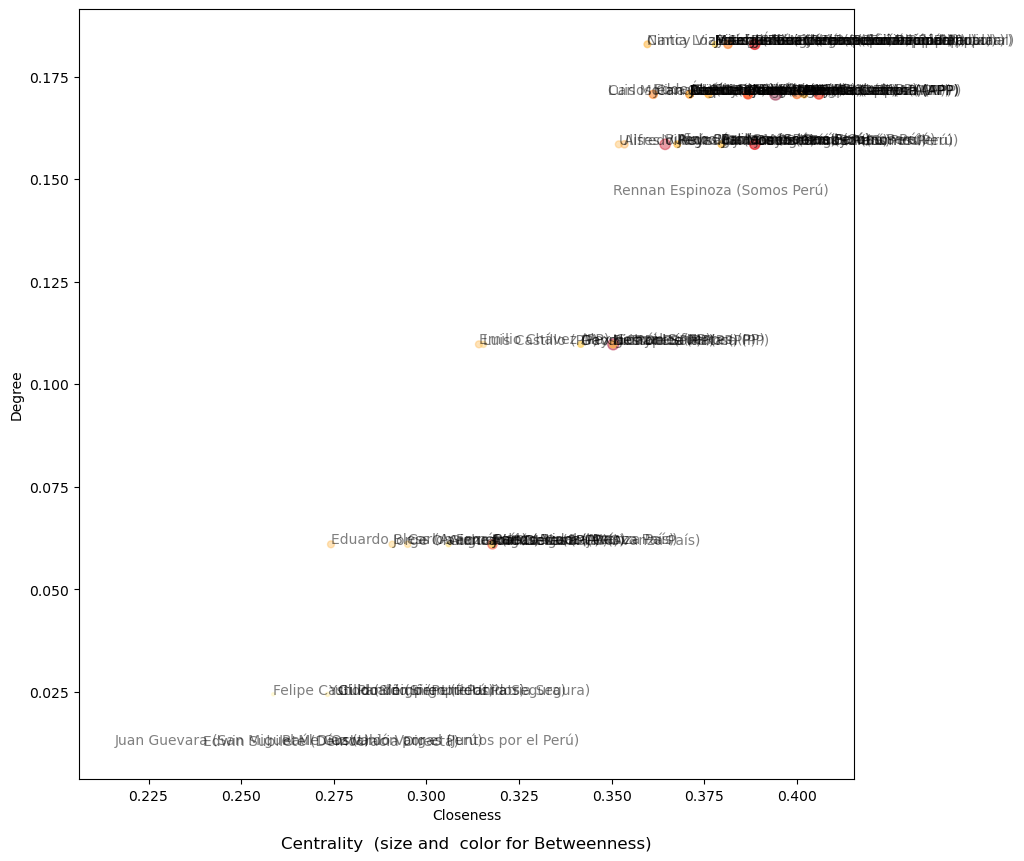

```python
import matplotlib.pyplot as plt

fig, ax = plt.subplots(figsize=(10,10))

ax.scatter(AlcaldeMeasures.Closeness, AlcaldeMeasures.Degree,s=1000*AlcaldeMeasures.Betweenness,
           c=100*AlcaldeMeasures.Betweenness,
           cmap=plt.get_cmap('YlOrRd'), alpha=0.4)

valsForAnnotate=zip(AlcaldeMeasures.index,AlcaldeMeasures.Closeness,AlcaldeMeasures.Degree)
for name,coordX,coordY in valsForAnnotate:
    ax.annotate(name, (coordX,coordY),alpha=0.5)

plt.title("Centrality  (size and  color for Betweenness)", y=-0.1)
plt.xlabel("Closeness")
plt.ylabel("Degree")
plt.show()
```

## Graficación final

El siguiente gráfico fue realizado con el apoyo de lso recursos de ChatGPT. Lo realicé para poder presentar la información con mucho más cuidado y claridad.

```python
#pip install dash plotly
```

```python
import networkx as nx
import dash
from dash import dcc, html
from dash.dependencies import Input, Output
import plotly.graph_objects as go

# Crear el grafo (suponiendo que tu grafo se llama 'Alcaldes')
G = Alcaldes

# Usar el layout spring para posicionar los nodos
pos = nx.spring_layout(G)

# Función para crear el gráfico
def create_graph(show_labels):
    # Obtener las posiciones de las aristas
    edge_x = []
    edge_y = []
    for edge in G.edges():
        x0, y0 = pos[edge[0]]
        x1, y1 = pos[edge[1]]
        edge_x.extend([x0, x1, None])
        edge_y.extend([y0, y1, None])

    # Crear el trazo para las aristas (líneas que conectan nodos)
    edge_trace = go.Scatter(
        x=edge_x, y=edge_y,
        line=dict(width=0.5, color='red', dash='dash'),  # Color y estilo de línea
        hoverinfo='none',
        mode='lines'
    )

    # Obtener las posiciones de los nodos
    node_x = []
    node_y = []
    for node in G.nodes():
        x, y = pos[node]
        node_x.append(x)
        node_y.append(y)

    # Crear el trazo para los nodos
    node_trace = go.Scatter(
        x=node_x, y=node_y,
        mode='markers',
        hoverinfo='none',  # No mostrar nombres al pasar el cursor
        marker=dict(
            color='yellow',  # Color de los nodos
            size=10,
            line_width=2),
    )

    # Crear el trazo para las etiquetas de los nodos (si se muestran)
    label_trace = go.Scatter(
        x=node_x, y=node_y,
        mode='text',
        text=list(G.nodes()),  # Etiquetas de los nodos
        textposition="bottom center",  # Posición de las etiquetas
        showlegend=False,
        visible='legendonly' if not show_labels else True  # Ocultar etiquetas si show_labels es False
    )

    # Crear la figura y configurarla como interactiva
    fig = go.Figure(data=[edge_trace, node_trace, label_trace],
                    layout=go.Layout(
                        title='<b>Red de Alcaldes distritales de Lima 2019-2022 y 2023-2026</b>',
                        titlefont_size=16,
                        showlegend=False,
                        hovermode='closest',
                        margin=dict(b=0, l=0, r=0, t=40),
                        xaxis=dict(showgrid=False, zeroline=False),
                        yaxis=dict(showgrid=False, zeroline=False))
                   )

    return fig

# Crear la aplicación Dash
app = dash.Dash(__name__)

# Layout de la aplicación
app.layout = html.Div([
    html.H1("Grafo Interactivo de Alcaldes"),
    dcc.Graph(id='graph', figure=create_graph(show_labels=True)),  # Por defecto, mostrar etiquetas
    html.Button("Mostrar/Ocultar", id='toggle-button', n_clicks=0)  # Botón para activar/desactivar nombres
])

# Callback para actualizar el gráfico
@app.callback(
    Output('graph', 'figure'),
    Input('toggle-button', 'n_clicks')
)
def update_graph(n_clicks):
    show_labels = n_clicks % 2 == 1  # Cambia la visibilidad de las etiquetas
    return create_graph(show_labels)

# Ejecutar la aplicación
if __name__ == '__main__':
    app.run_server(debug=False)
```

[interactive chart not shown]